# Unit_03_Project

Mahibah Jamal

2026-02-27

#Unit 03 Project

Below is a template to get you started on the Unit 3 Project. Make sure you edit the metadata above to include your name. For questions that include code, the template to produce R chunks is below. Any code you write that produces an output must be fully visible in the HTML document you hand in!

```r
library(tidyverse)
```

```r
library(ggplot2)
library(GGally)
library(MASS)
library(klaR)
library(maps)
library(dismo)
library(dplyr)
```

#Part 1 Morphological Data

##Question 1

The trait means for each species and column are listed below. There is some significant difference in the averages for petal length for setosa and petal length and petal width avarage compared to versicolor and virginia.

```r
iris %>%
  group_by(Species) %>%
  summarize(across(where(is.numeric), mean))
```

```
## # A tibble: 3 × 5
##   Species    Sepal.Length Sepal.Width Petal.Length Petal.Width
##   <fct>             <dbl>       <dbl>        <dbl>       <dbl>
## 1 setosa             5.01        3.43         1.46       0.246
## 2 versicolor         5.94        2.77         4.26       1.33
## 3 virginica          6.59        2.97         5.55       2.03
```

##Question 2

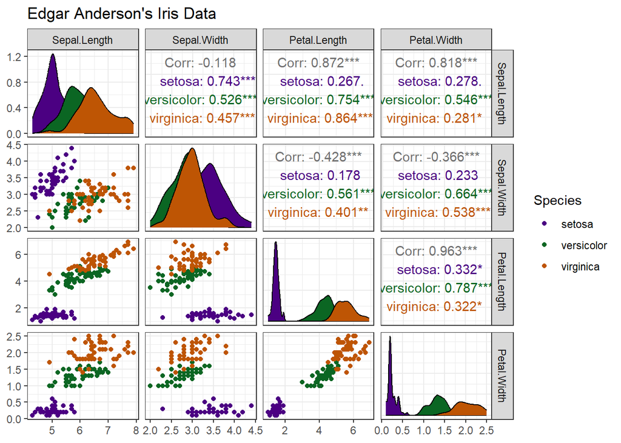

```r
ggpairs(iris, columns = 1:4, aes(color = Species), title = "Edgar Anderson's Iris Data",
        upper = list(continous = "points"),
        axisLabels = "show",
        legend = 10,
        columnlabels = colnames (data[columns])) +
  scale_color_manual (values = c("#4B0082", "#0B6623", "#BE5504")) +
  scale_fill_manual(values = c("#4B0082", "#0B6623", "#BE5504")) +
  theme_bw()
```

###Sepal Width & Sepal Length Graphs

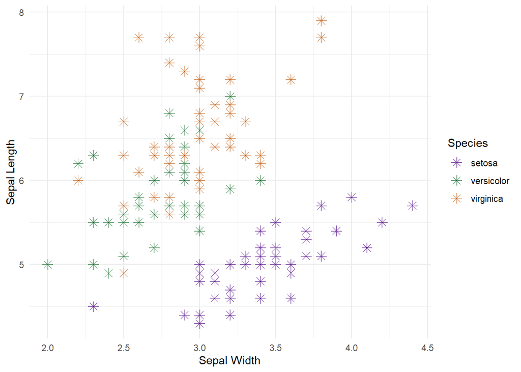

```r
ggplot(iris, aes( x = Sepal.Width, y = Sepal.Length, color = Species, group = Species)) +
  geom_point(size = 3, pch = 8) +
  labs (x = "Sepal Width", y = "Sepal Length") +
  theme_minimal() +
  scale_color_manual(values = c("#4B0082", "#0B6623", "#BE5504"))
```

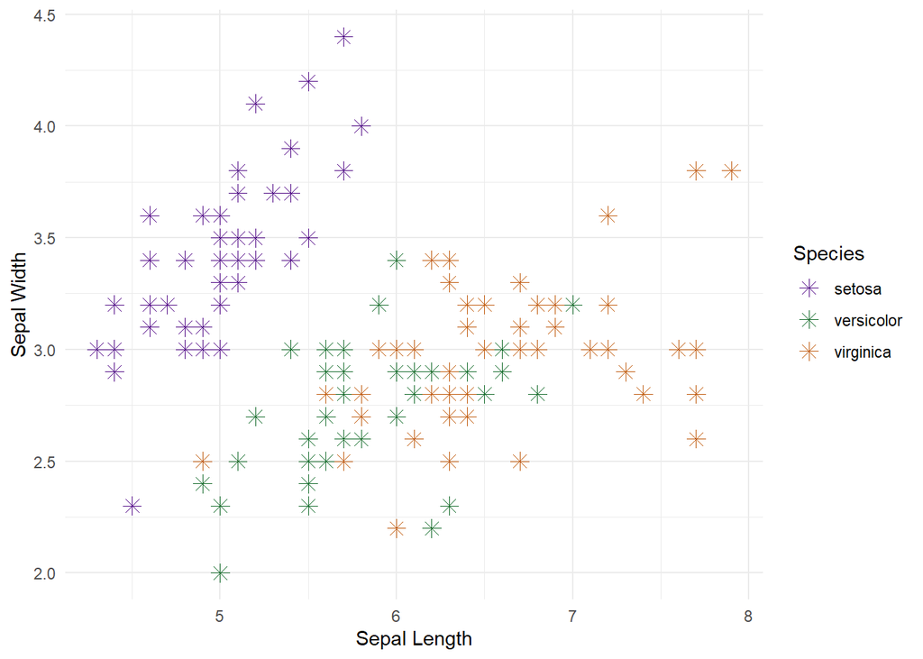

```r
ggplot(iris, aes( x = Sepal.Length, y = Sepal.Width, color = Species, group = Species)) +
  geom_point(size = 3, pch = 8) +
  labs (x = "Sepal Length", y = "Sepal Width") +
  theme_minimal() +
  scale_color_manual(values = c("#4B0082", "#0B6623", "#BE5504"))
```

###Petal Length & Sepal Length

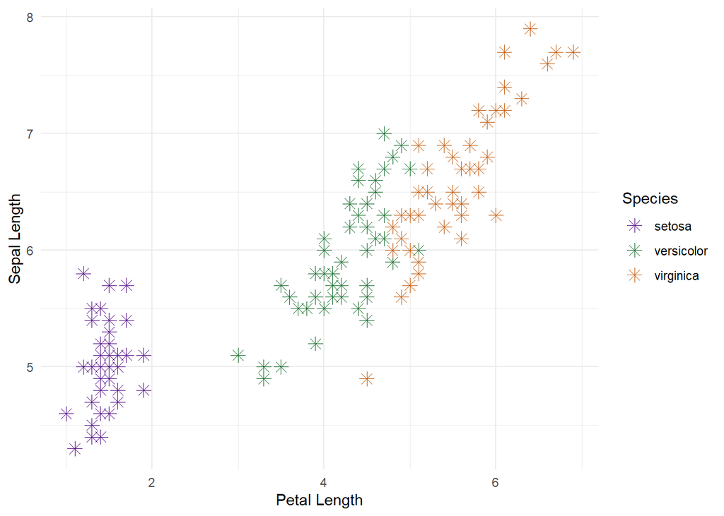

```r
ggplot(iris, aes( x = Petal.Length, y = Sepal.Length, color = Species, group = Species)) +
  geom_point(size = 3, pch = 8) +
  labs (x = "Petal Length", y = "Sepal Length") +
  theme_minimal() +
  scale_color_manual(values = c("#4B0082", "#0B6623", "#BE5504"))
```

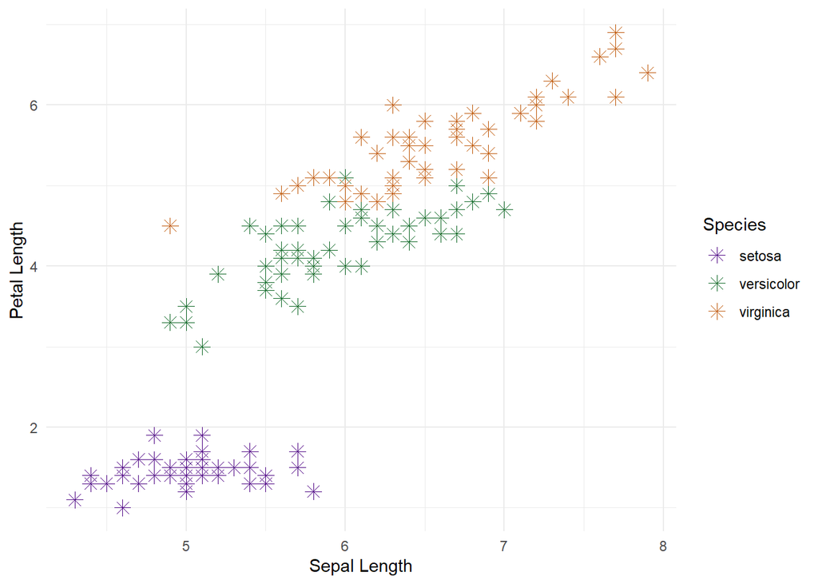

```r
ggplot(iris, aes( x = Sepal.Length, y = Petal.Length, color = Species, group = Species)) +
  geom_point(size = 3, pch = 8) +
  labs (x = "Sepal Length", y = "Petal Length") +
  theme_minimal() +
  scale_color_manual(values = c("#4B0082", "#0B6623", "#BE5504"))
```

###Petal Length & Petal Width Graphs

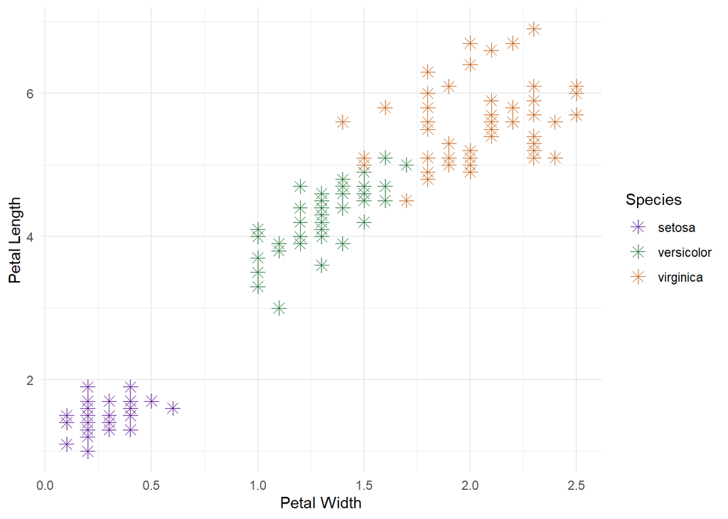

```r
ggplot(iris, aes( x = Petal.Width, y = Petal.Length, color = Species, group = Species)) +
  geom_point(size = 3, pch = 8) +
  labs (x = "Petal Width", y = "Petal Length") +
  theme_minimal() +
  scale_color_manual(values = c("#4B0082", "#0B6623", "#BE5504"))
```

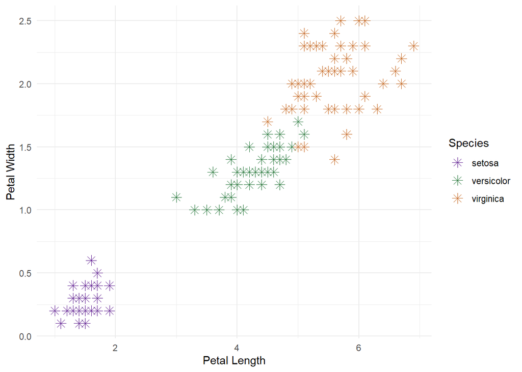

```r
ggplot(iris, aes( x = Petal.Length, y = Petal.Width, color = Species, group = Species)) +
  geom_point(size = 3, pch = 8) +
  labs (x = "Petal Length", y = "Petal Width") +
  theme_minimal() +
  scale_color_manual(values = c("#4B0082", "#0B6623", "#BE5504"))
```

###Sepal Width and Petal Width Graphs

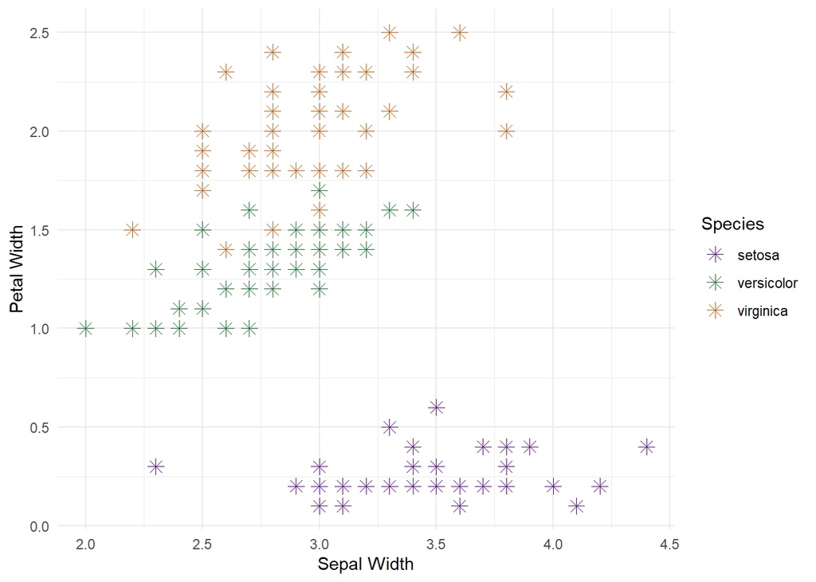

```r
ggplot(iris, aes( x = Sepal.Width, y = Petal.Width, color = Species, group = Species)) +
  geom_point(size = 3, pch = 8) +
  labs (x = "Sepal Width", y = "Petal Width") +
  theme_minimal() +
  scale_color_manual(values = c("#4B0082", "#0B6623", "#BE5504"))
```

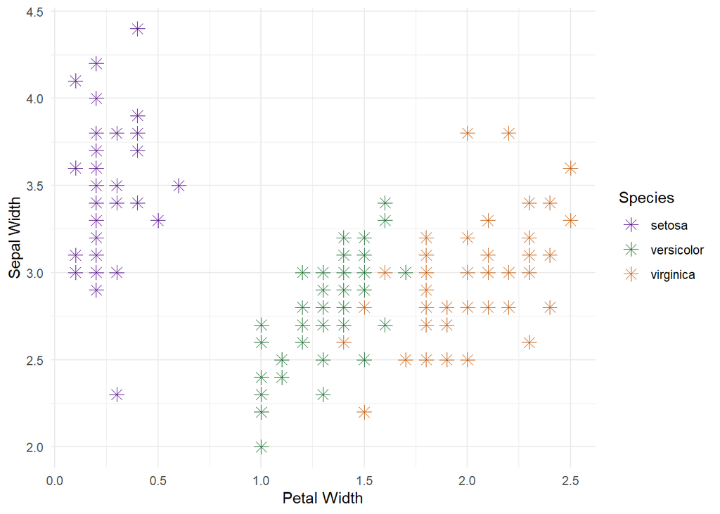

```r
ggplot(iris, aes( x = Petal.Width, y = Sepal.Width, color = Species, group = Species)) +
  geom_point(size = 3, pch = 8) +
  labs (x = "Petal Width", y = "Sepal Width") +
  theme_minimal() +
  scale_color_manual(values = c("#4B0082", "#0B6623", "#BE5504"))
```

###Sepal Length and Petal Width

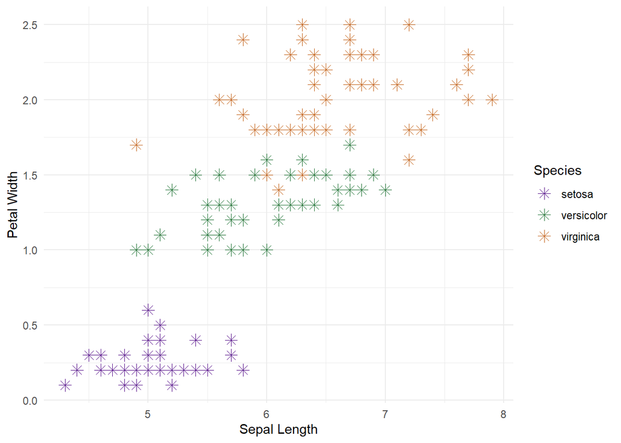

```r
ggplot(iris, aes( x = Sepal.Length, y = Petal.Width, color = Species, group = Species)) +
  geom_point(size = 3, pch = 8) +
  labs (x = "Sepal Length", y = "Petal Width") +
  theme_minimal() +
  scale_color_manual(values = c("#4B0082", "#0B6623", "#BE5504"))
```

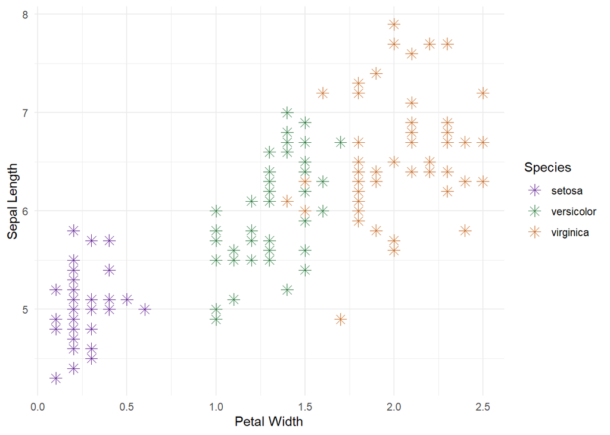

```r
ggplot(iris, aes( x = Petal.Width, y = Sepal.Length, color = Species, group = Species)) +
  geom_point(size = 3, pch = 8) +
  labs (x = "Petal Width", y = "Sepal Length") +
  theme_minimal() +
  scale_color_manual(values = c("#4B0082", "#0B6623", "#BE5504"))
```

###Sepal Width and Petal Length

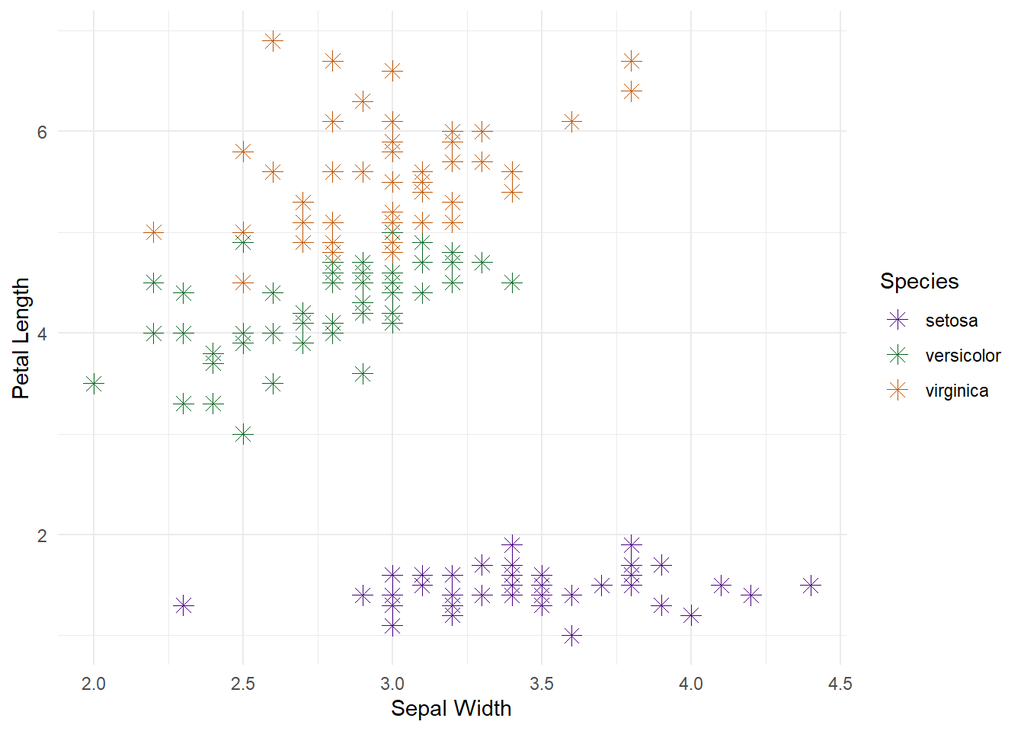

```r
ggplot(iris, aes( x = Sepal.Width, y = Petal.Length, color = Species, group = Species)) +
  geom_point(size = 3, pch = 8) +
  labs (x = "Sepal Width", y = "Petal Length") +
  theme_minimal() +
  scale_color_manual(values = c("#4B0082", "#0B6623", "#BE5504"))
```

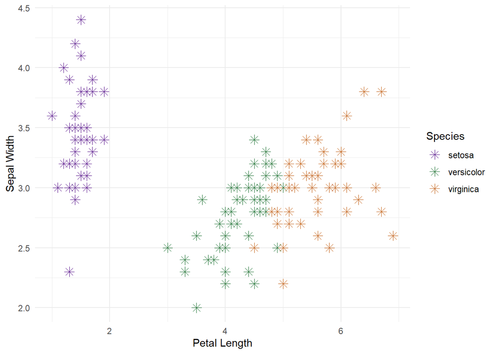

```r
ggplot(iris, aes( x = Petal.Length, y = Sepal.Width, color = Species, group = Species)) +
  geom_point(size = 3, pch = 8) +
  labs (x = "Petal Length", y = "Sepal Width") +
  theme_minimal() +
  scale_color_manual(values = c("#4B0082", "#0B6623", "#BE5504"))
```

##Question 3

```r
group <- iris %>%
  pull(Species)
Q3_widths <- iris %>%
  dplyr::select(Petal.Width, Sepal.Width)
Q3_widths_LDA <- lda(Q3_widths, group)
width <- stats::predict(Q3_widths_LDA, Q3_widths)
widths_preds <- width$class
widths_table <- table(iris$Species, width$class)
widths_table
```

```
##
##              setosa versicolor virginica
##   setosa         50          0         0
##   versicolor      0         49         1
##   virginica       0          4        46
```

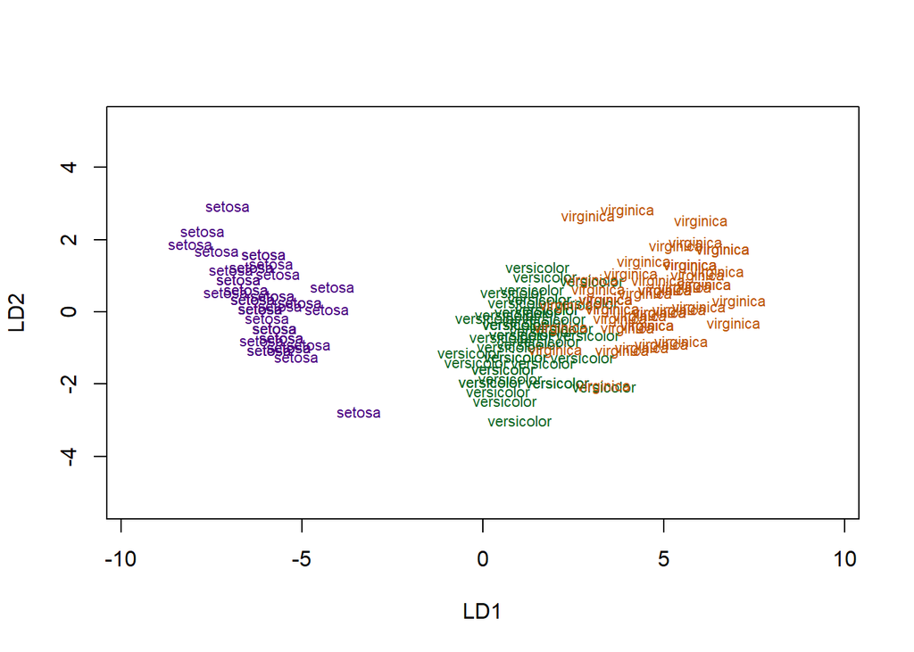

```r
iris_widths_preds <- iris %>%
  dplyr:: select(Species) %>%
  add_column(widths_preds)

plot(Q3_widths_LDA, col = c("#4B0082", "#0B6623", "#BE5504")
     [unclass(iris_widths_preds$Species)],
     xlim = c(-10, 10))
```

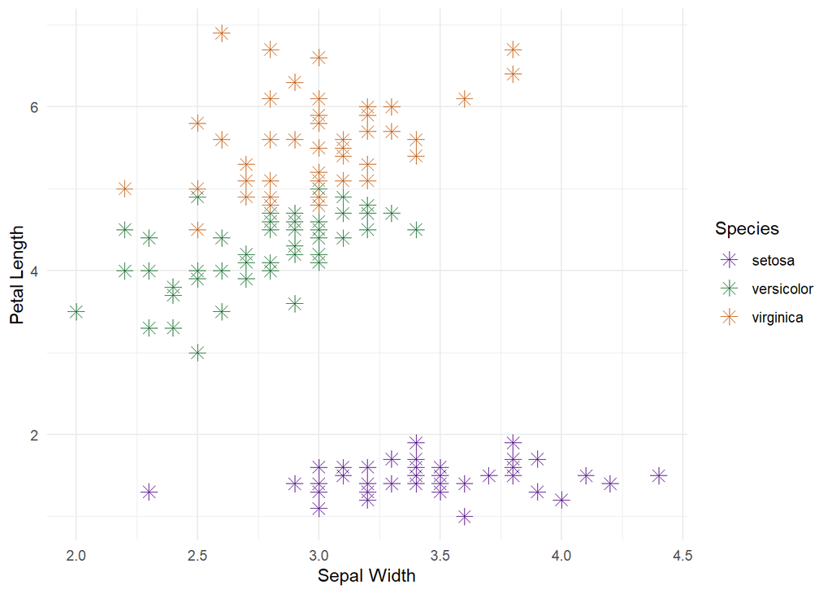

```r
ggplot(iris, aes( x = Sepal.Width, y = Petal.Length, color = Species, group = Species)) +
  geom_point(size = 3, pch = 8) +
  labs (x = "Sepal Width", y = "Petal Length") +
  theme_minimal() +
  scale_color_manual(values = c("#4B0082", "#0B6623", "#BE5504"))
```

```r
Q3_lengths <- iris %>%
  dplyr::select(Petal.Length, Sepal.Length)
Q3_lengths_LDA <- lda(Q3_lengths, group)

lengths <- stats::predict(Q3_lengths_LDA, Q3_lengths)

lengths_preds <- lengths$class

lengths_table <- table(iris$Species, lengths$class)

lengths_table
```

```
##
##              setosa versicolor virginica
##   setosa         50          0         0
##   versicolor      0         48         2
##   virginica       0          3        47
```

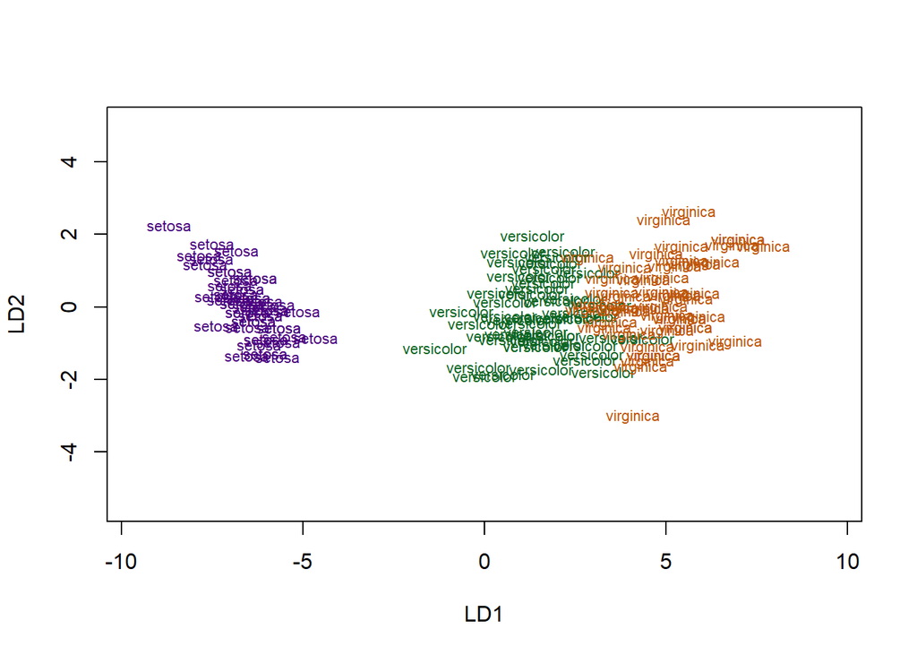

```r
iris_lengths_preds <- iris %>%
  dplyr::select(Species) %>%
  add_column(lengths_preds)

plot(Q3_lengths_LDA, col = c("#4B0082", "#0B6623", "#BE5504")
     [unclass(iris_lengths_preds$Species)],
     xlim = c(-10, 10))
```

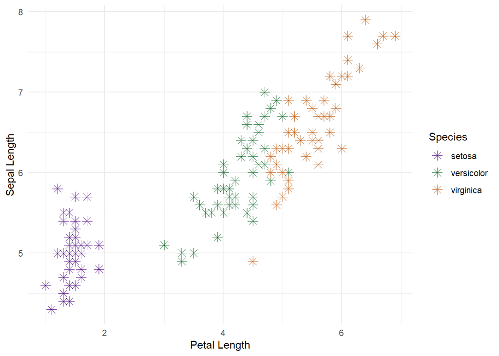

```r
ggplot(iris, aes(x = Petal.Length, y= Sepal.Length, color = Species, group = Species)) +
  geom_point(size = 3, pch = 8 ) +
  labs (x = "Petal Length", y = "Sepal Length") +
  theme_minimal() +
  scale_color_manual(values = c("#4B0082", "#0B6623", "#BE5504"))
```

##Question 4

I used the data in the Project 03 guide where there is the LDA for every combination of two variables. The plot with the lowest error rate (0.033) were Petal Width vs Sepal Width and Petal Length vs Sepal Length.

#Part II: Geographical & Temporal Data

##Question 1

Professor’s Code

```r
library(dismo)

get.gbif <- function(genus, species, na.rm = TRUE, crop = TRUE) {
    # GBIF query
    gps <- gbif(genus, species, geo = FALSE)
    # drop NA entries; note that this option is visited only with na.rm=TRUE
    if (na.rm) {
        gps <- subset(gps, !is.na(lon) & !is.na(lat))
    }
    if (crop) {
        keep <- c(which(colnames(gps) == "species"), which(colnames(gps) == "lat"), which(colnames(gps) == "lon"), which(colnames(gps) ==
            "month"))
        gps <- gps[keep]
    }
    return(gps)
}
```

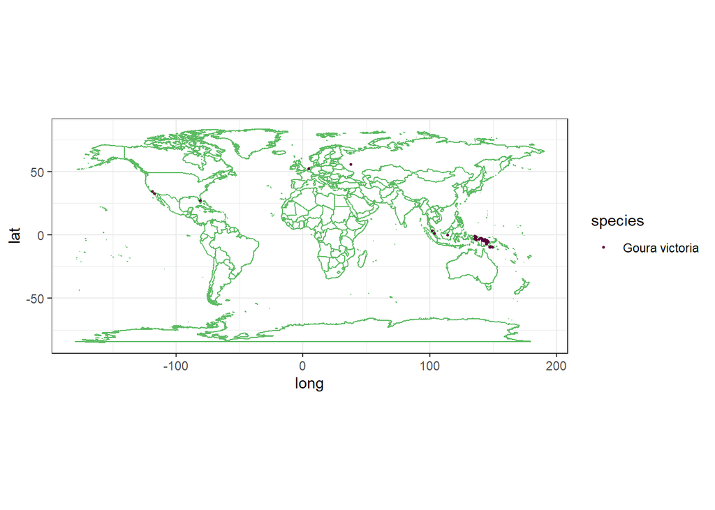

```r
#crown <- get.gbif("Goura", "victoria")

#write_csv(crown, file = "crown.csv", col_names = TRUE)

crown_csv <- read.csv("crown.csv", header = T, sep = ",")

ggplot2::theme_set(theme_bw())

world_map <- map_data(map = "world")

ggplot(world_map, aes(long, lat, group = group)) +
  geom_polygon(fill = "white", colour = "#5DBB63") +
  coord_quickmap() +
  geom_point( data = crown_csv, mapping = aes(x = lon, y = lat, group = species, color = species), size = 0.5) +
  scale_color_manual (values = c("#5c003c"))
```

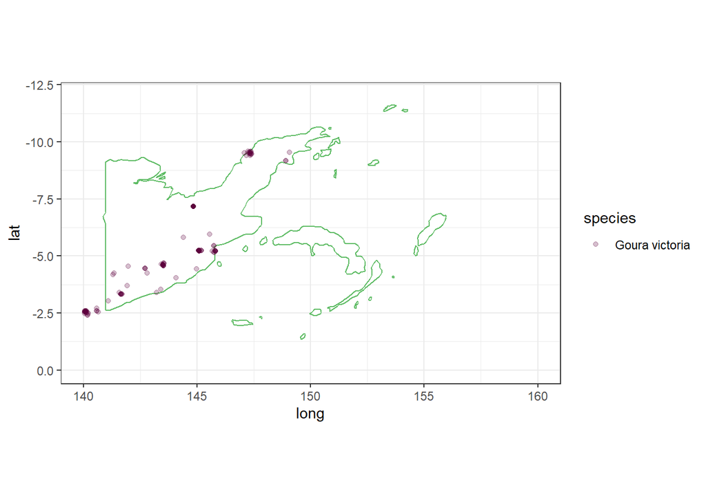

```r
papua_new_guinea_map <- map_data(map = "world", region = "papua new guinea")

ggplot(papua_new_guinea_map, aes(long, lat, group = group)) +
  geom_polygon(fill = "white", colour = "#5DBB63") +
  coord_quickmap() +
  geom_point(data = crown_csv, mapping = aes(x = lon, y = lat, group = species, color = species), size = 1.5, alpha = 0.25) +
  xlim(140, 160) +
  ylim(0, -12) +
  scale_color_manual(values = c("#5c003c"))
```

##Question 2

```r
iris_gps <- read.csv("iris_gps.csv", header = T, sep = ",")

US_map <- map_data(map = "usa")

US_map$long[which.max(US_map$long)]
```

```
## [1] -67.00742
```

```r
US_map$long[which.min(US_map$long)]
```

```
## [1] -124.6813
```

```r
US_map$lat[which.max(US_map$lat)]
```

```
## [1] 49.38323
```

```r
US_map$lat[which.min(US_map$lat)]
```

```
## [1] 25.12993
```

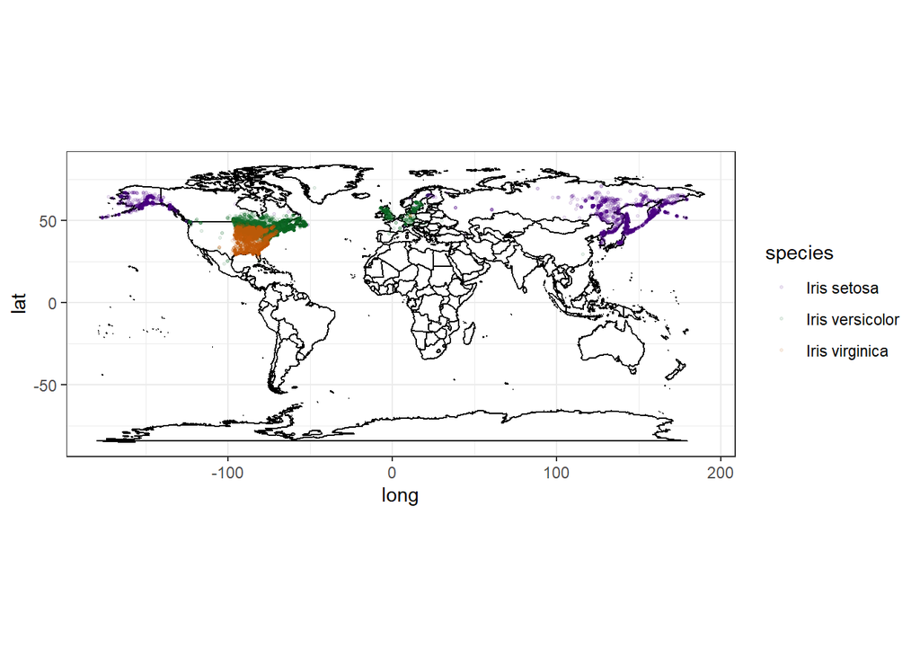

```r
iris_gps_USA <- iris_gps %>%
  dplyr::filter(lon >= -124.6813) %>%
  dplyr::filter(lon <= -67.00742) %>%
  dplyr::filter(lat >= 25.12993) %>%
  dplyr::filter(lat <= 49.38323)

ggplot(world_map, aes(long, lat, group = group)) +
  geom_polygon(fill = "white", colour = "black") +
  coord_quickmap() +
  geom_point(data = iris_gps, mapping = aes( x = lon, y = lat, group = species, color = species), size = 0.5, alpha = 0.1) + scale_color_manual(values = c("#4B0082", "#0B6623", "#BE5504"))
```

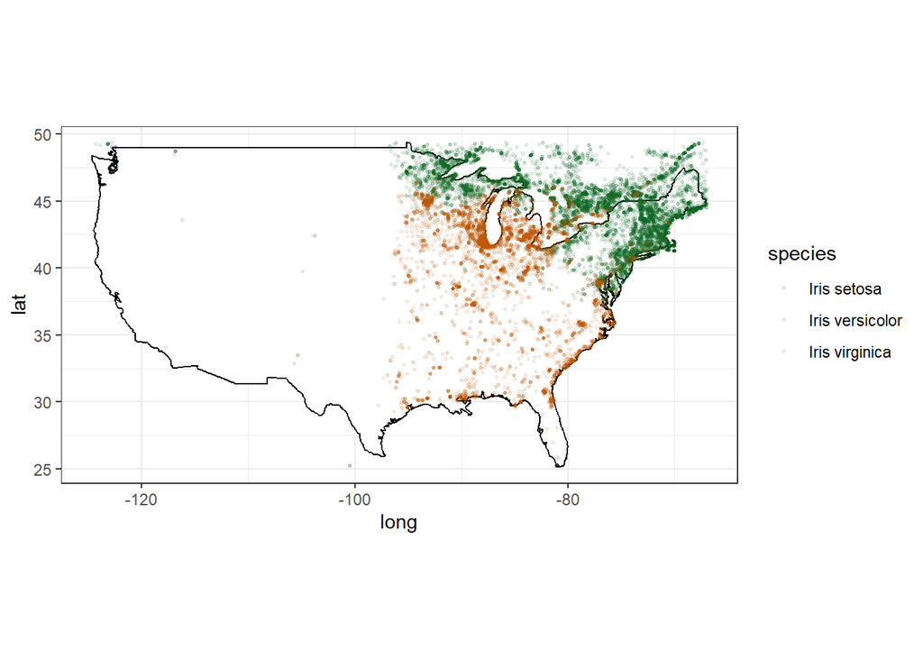

```r
ggplot(US_map, aes(long, lat, group = group)) +
   geom_polygon(fill = "white", colour = "black") +
  coord_quickmap() +
  geom_point(data = iris_gps_USA, mapping = aes( x = lon, y = lat, group = species, color = species), size = 0.5, alpha = 0.1) +
  scale_color_manual(values = c("#4B0082", "#0B6623", "#BE5504"))
```

##Question 3

```r
iris_gps_Northeast <- iris_gps_USA %>%
    dplyr::filter(lon >= -72) %>%
    dplyr::filter(lon <= -68) %>%
    dplyr::filter(lat >= 43) %>%
    dplyr::filter(lat <= 45)
```

```r
US_Northeast <- US_map %>%
    dplyr::filter(long >= -72) %>%
    dplyr::filter(long <= -68) %>%
    dplyr::filter(lat >= 43) %>%
    dplyr::filter(lat <= 45)
```

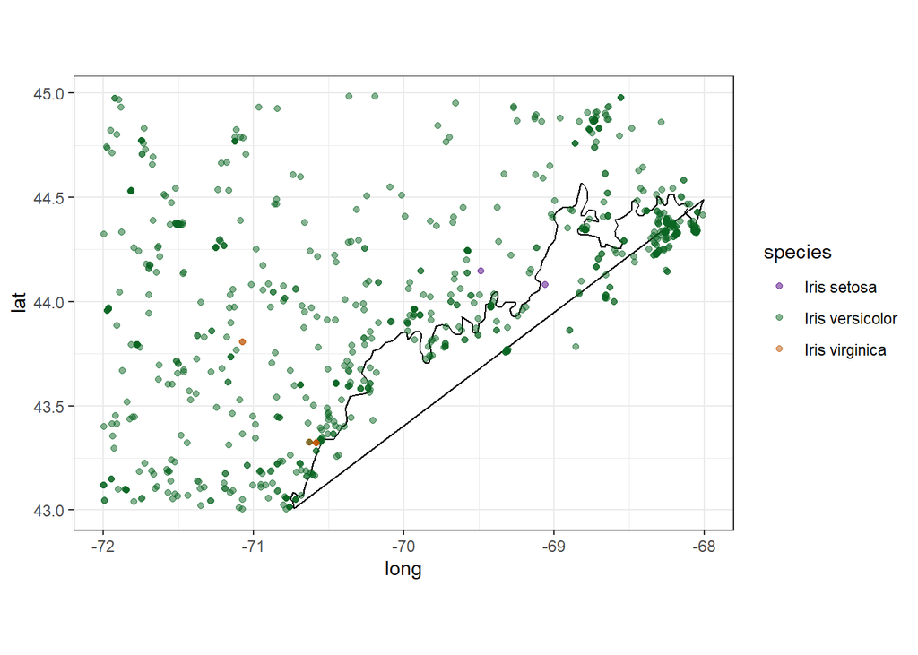

```r
ggplot(US_Northeast, aes(long, lat, group = group)) +
  geom_polygon(fill = "white", colour = "black") +
  coord_quickmap() +
  geom_point(data = iris_gps_Northeast, mapping = aes(x = lon, y = lat, group = species, color = species), size = 1.5, alpha = 0.5) +
  scale_color_manual( values = c("#4B0082", "#0B6623", "#BE5504"))
```

##Question 4

This data can support that *virginica* and *versicolor* can be considered to be different species because there is some overlap in their distribution, but there are other regions where they do no co-occur. To add on the number of obsersvations of *setosa* that occur in the mass of *versicolor* can also hint at some misidentification, after all there is the factor of human error / bias when observations are being made and reported.

##Question 5

It’s difficult to come to a conclusion with this data for reproductive isolation because they have similar flowering times; there is always at least one month of overlap between the three species. No conclusion about species designation for three different species can be drawn or supported with this temporal data. Flowering period is being used an indicator of reproduction but there is no way to confirm that the dlowers are being fertilized / producing gametes, we also don’t know their modes of pollination and the weather / timing criteria that need to be met.

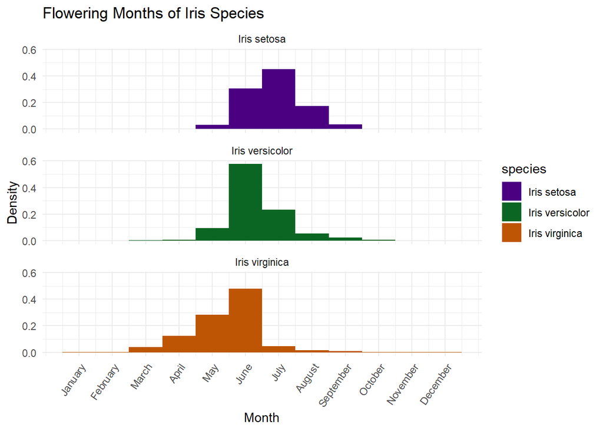

```r
ggplot(data = iris_gps, aes( x = month, y = after_stat(density), group = species, fill = species)) +
  geom_histogram(position = "dodge", binwidth = 1) +
  facet_wrap (~species, nrow = 3) +
  xlim(1, 12) +
  theme_minimal() +
  scale_x_continuous(breaks = seq_along(month.name),
    labels = month.name) +
  theme(axis.text.x = element_text(angle = 55, hjust = 1)) +
  labs (x= "Month", y = "Density", title = "Flowering Months of Iris Species") +
  scale_fill_manual(values = c("#4B0082", "#0B6623", "#BE5504"))
```

#Part III: Chromosomal Data

##Question 1

```r
iris_chromos_dataset <-read_csv("iris_chromosomes.csv", skip = 1, col_names = T, trim_ws = T, skip_empty_rows = T)
iris_chromos <- iris_chromos_dataset %>%
  dplyr::select(resolved_name, sporophytic, parsed_n) %>%
  separate(resolved_name, into = c("genus", "species"), sep = " ", remove = TRUE, extra = "drop")

iris_chromos <- drop_na(iris_chromos)

iris_chromos <- iris_chromos %>%
  mutate(cleaned_spor = str_replace_all(iris_chromos$sporophytic, "2n =", ""))

iris_chromos <- iris_chromos %>%
  dplyr::select(-sporophytic)

iris_chromos <- iris_chromos %>% mutate(valid = str_detect(cleaned_spor, "^...$|^..$"))

iris_valid <- iris_chromos %>%
  filter (valid == T)

iris_invalid <- iris_chromos %>%
  filter (valid == F)

iris_coms <- iris_invalid %>%
  filter(str_detect(cleaned_spor, ",") == T)

iris_others <- iris_invalid %>%
  filter(str_detect(cleaned_spor, ",") == F)

cleaned_iris_coms <-iris_coms %>%
    slice(-10, -11, -12, -32, -44, -46, -49, -55, -58, -63) %>%
    separate_longer_delim(c(cleaned_spor, parsed_n), delim = ",")

cleaned_iris_chromos <- bind_rows(iris_valid, cleaned_iris_coms) %>%
  dplyr::select(- valid)

colnames(cleaned_iris_chromos) <- c("genus", "species", "parsed_n", "sporophytic")

str(cleaned_iris_chromos)
```

```
## tibble [1,240 × 4] (S3: tbl_df/tbl/data.frame)
##  $ genus      : chr [1:1240] "Iris" "Iris" "Iris" "Iris" ...
##  $ species    : chr [1:1240] "acutiloba" "acutiloba" "acutiloba" "acutiloba" ...
##  $ parsed_n   : chr [1:1240] "10" "10" "10" "10" ...
##  $ sporophytic: chr [1:1240] "20" "20" "20" "20" ...
```

```r
cleaned_iris_chromos$sporophytic <- as.numeric(cleaned_iris_chromos$sporophytic)

cleaned_iris_chromos$parsed_n <- as.numeric(cleaned_iris_chromos$parsed_n)

str(cleaned_iris_chromos)
```

```
## tibble [1,240 × 4] (S3: tbl_df/tbl/data.frame)
##  $ genus      : chr [1:1240] "Iris" "Iris" "Iris" "Iris" ...
##  $ species    : chr [1:1240] "acutiloba" "acutiloba" "acutiloba" "acutiloba" ...
##  $ parsed_n   : num [1:1240] 10 10 10 10 10 10 10 10 11 11 ...
##  $ sporophytic: num [1:1240] 20 20 20 20 20 20 20 20 22 22 ...
```

```r
Mode <- function(x) {
  ux <- unique(x)
  ux[which.max(tabulate(match(x, ux)))]}

cleaned_iris_chromos_mode <- cleaned_iris_chromos %>%
  group_by(species) %>%
 summarize(across(where(is.numeric), Mode))

cleaned_iris_chromos_mode %>%
  print(n = 20)
```

```
## # A tibble: 211 × 3
##    species        parsed_n sporophytic
##    <chr>             <dbl>       <dbl>
##  1 acutiloba            10          20
##  2 afghanica            11          22
##  3 aitchisonii          17          34
##  4 alberti              12          24
##  5 albicans             22          44
##  6 albomarginata        25          50
##  7 anguifuga            17          34
##  8 antilibanotica       10          20
##  9 aphylla              24          48
## 10 arenaria             11          22
## 11 assadiana            10          20
## 12 atrofusca            10          20
## 13 atropatana            9          18
## 14 atropurpurea         10          20
## 15 aucheri              12          24
## 16 auranitica           10          20
## 17 barnumiae            10          20
## 18 basaltica            10          20
## 19 bicapitata           20          40
## 20 biglumis             20          40
## # ℹ 191 more rows
```

##Question 2

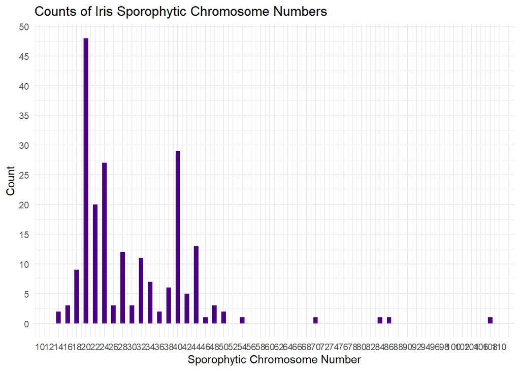

```r
ggplot(data = cleaned_iris_chromos_mode, aes(x = sporophytic, group = species)) +
  geom_histogram(binwidth = 1, fill = "#4B0082") +
  scale_x_continuous(breaks = seq(0, 110, by = 2)) +
  scale_y_continuous(breaks = seq(0, 50, by = 5)) +
  theme_minimal() +
  labs(x = "Sporophytic Chromosome Number", y = "Count", title = "Counts of Iris Sporophytic Chromosome Numbers")
```

##Question 3

Modes for Sporophytic Stage Chromosome Counts *Setosa* = 38 *Versicolor* = 108 *Virginica* = 70

These numbers support the hybrid theory as *setosa* and *virginica* chromosome counts added together equal the chromosome count for *versicolor*.

```r
cleaned_iris_chromos_mode %>%
  slice(166, 197, 199)
```

```
## # A tibble: 3 × 3
##   species    parsed_n sporophytic
##   <chr>         <dbl>       <dbl>
## 1 setosa           19          38
## 2 versicolor       54         108
## 3 virginica        35          70
```

#Part IV: Producing a Scientific Argument

##Question 1

I would say that the bet supported relationship between these three species of Iris is that they are three distinct species. The chromosome count data supports that *Iris versicolor* is a result of hybridization between *iris setosa* and *Iris virginica*. When factoring in the morphological data there can be an argument that some of the characteristics can be used to determine the different species using LDA and a few of the measurements. When looking at the map data and the geography of the Iris distribution it is obvious *setosa* is the species that is different based on it’s range. One hypothesis could be an early divergence event occured, most likely a phyical barrier that allowed the Iris to speciate but still leaving the potential to interbreed. Temporally, again, *versicolor* is landing betwtween *virginica* and *setosa*. The chromosomal data as I mentioned earlier for *versicolor* also is the sum of the chromosome counts of *virginica* and *setosa*.

The most compelling data for me was the chromosome counts and after that I would say the morphological data. To be honest it seems like it would be really rare for the chromosome counts to line up as they do and also have morphological data supporting the theory of *versicolor* being a hybrid of the other two. I don’t know how much I can rely on temporal data because due to changes in weather pattern, flowering times have been shifting all over the world.

I would say the original species designations by Anderson were correct based off the data that we’ve computed in class, but there is still room for doubt due to the consistent overlap in the data for *virginica* and *versicolor*. I would say the additional, geographic, temporal, and chromosomal data, aided in the argument because they provided evidence supporting the species designations.

Given the relationship above, I would say these organisms represent three species and the reasoning is what I wrote above. I find the case of *versicolor* very interesting, especially even the LDA missclassified some points with *virginica*